# Bayes Universe

```python
#Packages

from IPython.display import Image
import numpy as np
from scipy.special import gamma
from scipy.stats import beta
from matplotlib import pyplot as plt
from matplotlib.pyplot import figure
```

# Probability - A philosophical question

What is probabilty? This seemingly trivial question leads to stark differencen in analytical approaches. Generally, frequentists are primarily concerned with the past, while Bayesians are focused on the future. The difference in perspective stems from two distic definitions of if probabiltity: Frequentist - defines probability through repeated measurements of events of past events Bayesian - defines probabitly throught prior information about an events

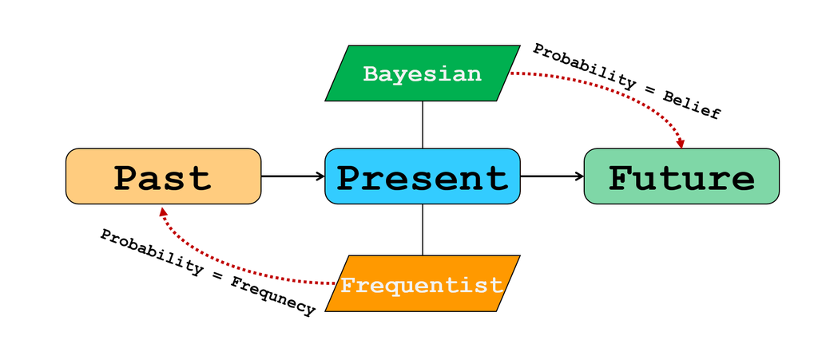

```python
Image(filename="img/What-Is-Probability.png")
```

# Bayes Theorem

For two events A and B with P(B)> 0 the probability of A can be determined under the condition that B has been calculated by the probability of B under the condition that has occurred. This can be written as follows (note that the notation chosen fits Machine Learning purposes):

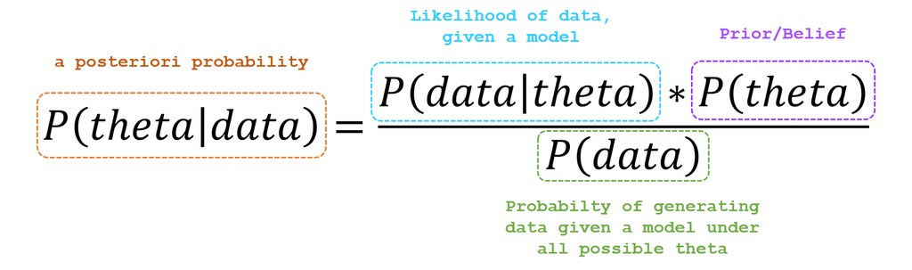

```python
Image(filename= "img/Bayes Theorem.png")
```

P(theta|data) is the probabitly distribtuon over model parameters we get, after taking into account prior beliefs and information P(data|theta) is the probability defined by a specific model and its parameters P(theta) is our belief or prior knowledge regarding model parameter P(data) reflects the probabilty of deriving this data from a spcific model, considering all possible thetas. Hence, P(data) can be expressed as follows:

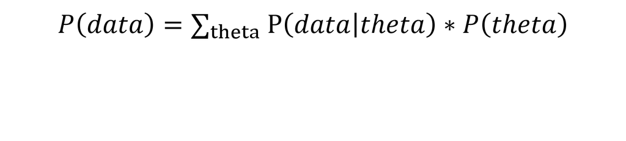

```python
Image(filename="img/Formel2.png")
```

Incorporating this expression in to Bayes Rule gives:

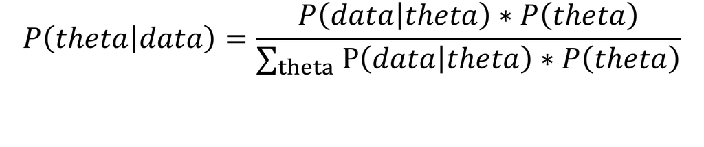

```python
Image(filename="img/Formel3.png")
```

# Maximum Likelihood Estimation - MLE

Maximum likelihood estimation (MLE), is a framework for inference for finding the best statistical estimates of parameters from historical training data. It can be defined as a method for estimating parameters (such as the mean or variance ) from sample data such that the probability (likelihood) of obtaining the observed data is maximized.

A common modeling problem involves how to estimate a joint probability distribution for a dataset. The joint probability distribution can be restated as the multiplication of the conditional probability for observing each example given the distribution parameters. The density estimation involves selecting a probability distribution function and the parameters of that distribution that best explain the joint probability distribution of the observed data (X). One way to interpret MLE is to view it as minimizing the dissimilarity between the empirical distribution […] defined by the training set and the model distribution, with the degree of dissimilarity between the two measured by the KL divergence. […] Minimizing this KL divergence corresponds exactly to minimizing the cross-entropy between the distributions.

In MLE, we wish to maximize the probability of observing the data from the joint probability distribution given a specific probability distribution and its parameter, which, in the context of Bayes MLE gives a point esteimate for theta that maximizes P(data|theta)

# Maximimum A posteriorii Estimation - MAP

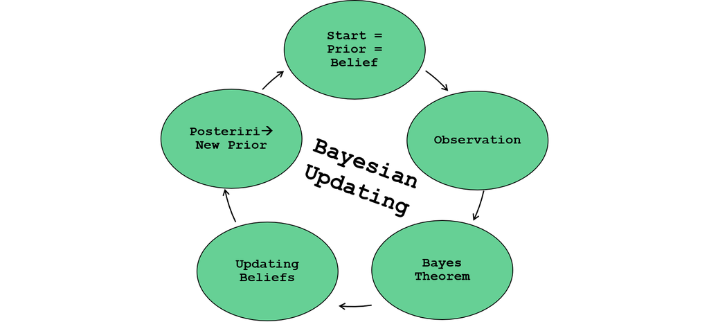

```python
Image(filename="img/Bayesian-Updating.png")
```

# Bayesian Inference

Both Bayesian Inference as well as MAP rest on Bayes's theorem. Unlike MLE or MAP, Bayesian infernce gives the full the posteriori probability distribution, which is called density or mass function The major computational difference is that under Bayes's theorem we need to calculate P(data), also called marginal likelyhood. P(data) is the denominator in the above stated forumula and ensures the integrated sum of P(theta|data) over all possible thetas becomes 1 (If theta is a discrete variable). This is called marginalization, which essentially involves summing over all possible values of one variable to determine the marginal contribution of another The variable which is summed up is called the nuisance variable. Integrating the denominator with respect to nuisance variable is only necessary if the scale of variable at hand is within given boundaries (continuous variable). Otherwise summing up the element in the denominator does the job.

# MLE vs MAP vs Bayes Inference

Consinder a Counter-Strike Go E-Sports tournament one vs. one match. There are two player: Palyer X has a record of 58 mateches with 41 wins Player Y has a record of 8 matches with 6 wins

Let a=b=2 be hyperparameters of a Beta distribution (discussed in further detail below)

Assume that player X won 50% of games last season. Since player Y did not participate in the CS Go league last year, we also assume a 50% winning chance.

Furher assume that winning/losing follows a Bernoulli trial with winning probabitly theta, which is defined through:

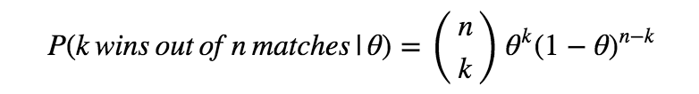

```python
Image(filename="img/bernoullitrail.png")
```

```python
#Player X
player_x = 41
player_x_n = 58

#Player Y
player_y = 6
player_y_n = 8

# beta parameters
parameter_a = 2
parameter_b = 2
```

## MLE - Example

```python
#Calculating MLE
MLE_X = player_x / player_x_n
MLE_Y =  player_y / player_y_n
print("MLE for player X", MLE_X)
print("MLE for player Y", MLE_Y)
```

```
MLE for player X 0.7068965517241379
MLE for player Y 0.75
```

If we solely look at MLE, any bests should be places on palyer Y, since he/she has a slightly higher chance of winning. But is this really the cases? Let us have a look what MAP has to say about this situation.

## MAP - Example

To calculate MAP, we use Bayes Theorem. Since we are only interested in finding a value for theta that maximizes P(theta|data), we can ingnore P(data) since it is independent to theta. Thus the following formula applies

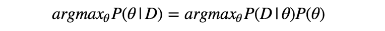

```python
Image(filename="img/MAP.PNG")
```

## Beta Distribution

For computational simplicity, we use a Beta distributon

A beta distribution is a continuous probability distributions over the interval(0,1),parameterized by two parameters (α and β).

In this example the beta distribution is used as the conjugated a priori probability distribution for the Bernoulli distribution.

The following formula defines the beta distribution:

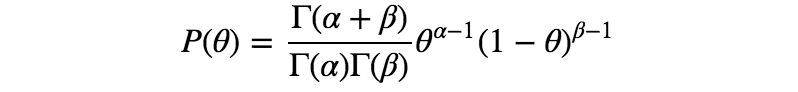

```python
Image(filename="img/Beta.png")
```

The Beta distribution's hyperparameters cannot be determinded by data. They are set based on prior knowledge. Note that if a = b = 1 than this represents zero prior knowldege and MAP would be equal to MLE.

The following sections illustrates the beta distributon's parameter dependency

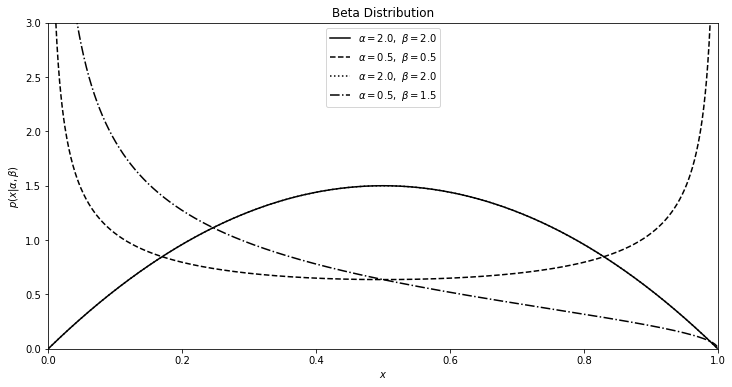

```python
# Plotting Beta distributons
# Define the distribution parameters to be plotted
alpha_values = [2, 0.5, 2.0, 0.5]
beta_values = [2, 0.5, 2.0, 1.5]
linestyles = ['-', '--', ':', '-.']
x = np.linspace(0, 1, 1002)[1:-1]

#------------------------------------------------------------
# plot the distributions
fig, ax = plt.subplots(figsize=(12, 6))

for a, b, ls in zip(alpha_values, beta_values, linestyles):
    dist = beta(a, b)

    plt.plot(x, dist.pdf(x), ls=ls, c='black',
             label=r'$\alpha=%.1f,\ \beta=%.1f$' % (a, b))

plt.xlim(0, 1)
plt.ylim(0, 3)

plt.xlabel('$x$')
plt.ylabel(r'$p(x|\alpha,\beta)$')
plt.title('Beta Distribution')

plt.legend(loc=0)
plt.show()
```

## Incorporating Bernoulli and Beta

Now that we have defined the Bernoulli distributon and the Beta distributon, it is time to incorporate these concepts into Bayes Theroem, wich yields:

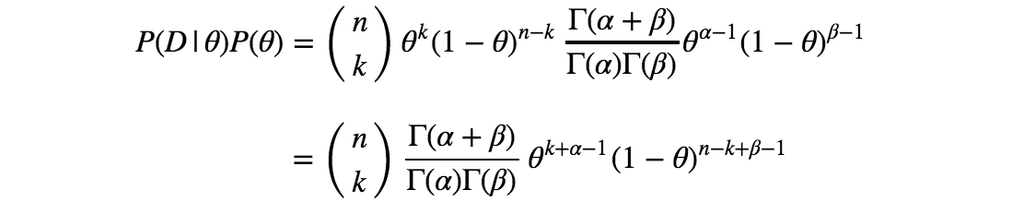

```python
Image(filename="img/Binomial+Beta.png")
```

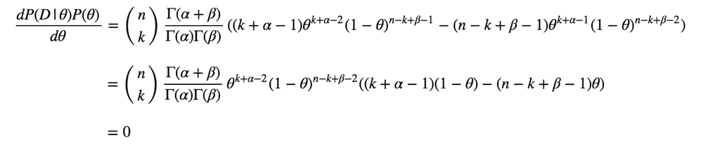

```python
Image(filename="img/posteriori1.png")
```

This can be simplified to:

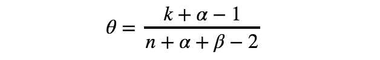

```python
Image(filename="img/posteriori2.png")
```

```python
MAP_X = (player_x + parameter_a -1) / (player_x_n + parameter_a + parameter_b  - 2)
MAP_Y = (player_y + parameter_a -1) / (player_y_n + parameter_a + parameter_b  - 2)

print("MAP for Player X", MAP_X)
print("MAP for Player Y", MAP_Y)
```

```
MAP for Player X 0.7
MAP for Player Y 0.7
```

Things look a bit different now. Under MAP, both player appear to be equally likley to win the match. Let us cacluate the entire distribution of theat to get a better understanding whats really going on.

## Bayesian Inference Example

As mentioned before, we need to integrade over the denominator to derive the nuisance term.

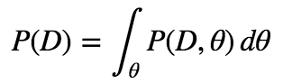

```python
# #alculating pasteriori probabitly distribution
Image(filename="img/Ptheta.png")
```

### Chain Rule for probability

Applying the chain rule for porbabilty (not to be confused with the chain rule for differentiation) yields.

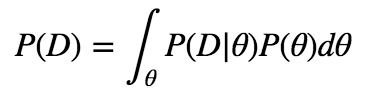

```python
# The chain rule of probabilry gives:
Image(filename="img/chainruleptheta.png")
```

Thus, Bayes theorem can be stated as follows:

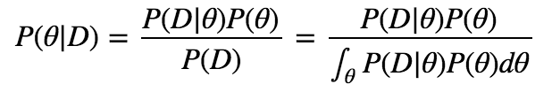

```python
# which leads to
Image(filename="img/BayesInference1.png")
```

Adding our definitions for Bernoulli and Beta distributon to the expression above gives:

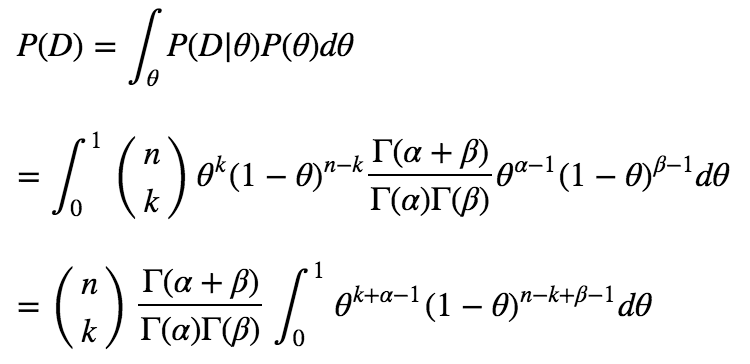

```python
# following theses steps

Image(filename="img/Ptheta2.png")
```

Using the gamma function (Euler integral of first kind), the formula above can be trandformed to:

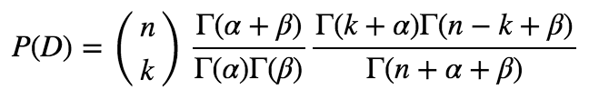

```python
Image(filename="img/Ptheta3.png")
```

Plugging these experssions into Bayes Theorem ultimately yields:

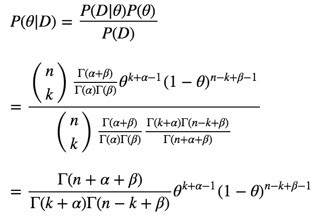

```python
#Finally, we can obtain P(θ|D) as below.
Image(filename="img/BayesFinal.png")
```

```python
def posteriorii(k_post, n_post, alpha_post, beta_post):
    posteriorii_p = list()
    theta = np.arange(0, 1, 0.01)
    for i in theta:
        p = (gamma(n_post+alpha_post+beta_post) / (gamma(k_post+alpha_post) * gamma(n_post-k_post+beta_post))) * (i**(k_post+alpha_post-1)) * ((1-i)**(n_post-k_post+beta_post-1))
        posteriorii_p.append(p)
    return posteriorii_p
```

```python
posterioiri_player_y = posteriorii(player_y, player_y_n, parameter_a , parameter_b)
posterioiri_player_x = posteriorii(player_x, player_x_n, parameter_a , parameter_b)
```

```python
posterioiri_player_y = posteriorii(player_y, player_y_n, parameter_a , parameter_b)
posterioiri_player_x = posteriorii(player_x, player_x_n, parameter_a , parameter_b)
```

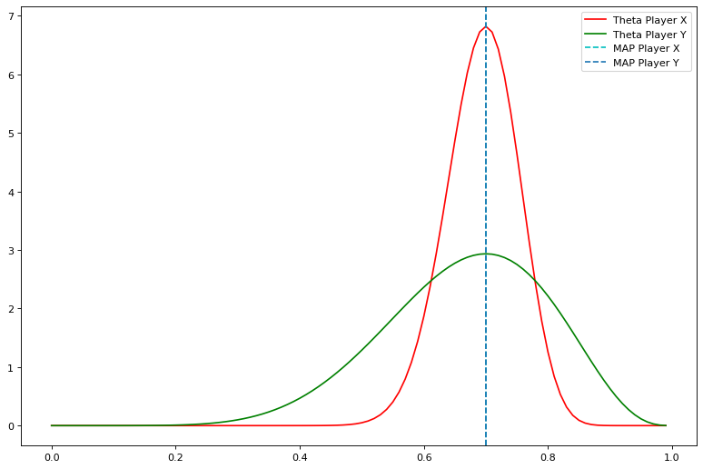

```python
figure(num=None, figsize=(12, 8), dpi=80)
theta = np.arange(0, 1, 0.01)

plt.plot(theta, posterioiri_player_x, "r", label = "Theta Player X")
plt.plot(theta, posterioiri_player_y, "g", label = "Theta Player Y")
plt.axvline(MAP_X, 0, 7, label = "MAP Player X", linestyle = "--", color = "c")
plt.axvline(MAP_Y, 0, 7, label = "MAP Player Y", linestyle = "--")

plt.legend()
plt.show()
```

The plot above clearly shows the the difference between MAP and Bayesian Inference, Under MAP, both players appear to have the same point estimate of theta. But looking at the entire distribution of theta yield a different picture, with player X's theta being much closer centered around the mode of 0.7 compared to player Y.

# Markov Chain Monte Carlo - MCMC

Consindering the "simple" example above, it becomes evident that calculating the demoniator P(data) is computationally expensive (integration with respect to all possible values of paramets), if the problem at hand becomes more complex. In fact, if we increase the parameters for, say, player X to player_x = 162 and player_x_n = 231, Python (on my machine) refuses to perform the calculation.

A solution to this problem is substituting the direct integral computation wiht a method called Markov chain Monte Carlo.

Essentially MCMC generates samples from the posteriori distribution by constructing a reversible Markov-chain that has as its equilibrium distribution the target posteriori distribution

## Markov Chain

A Markow chain is a stochastic process and defined by the fact that even with limited knowledge predictions about future developments are as good as with complete knowledge of a particular process.

The Chaper on "Reinforcement Learning" covers Makov Chains in greater depht.

## Monte Carlo Simulation

Monte Carlo simulation is a stochastic process of random experiments that rests on the law fo lare number and probability theory to solve problems numerically, wich cannot be solves analytically. Usually random experiments are simulated by using algorithms such as the Metropolis-Hastings algorithm or Hamiltonian algorithm, but can also be real experiments.

## MCMC using Metropolis-Hastings

1. chose a starting positioin (can ba arbitrat) mh_current = 1
1. MH takes a random sample from a normal distribution centered around the starting point with a particular standard deviation, which determines the magnitude of jumps mh_proposed = norm(mh_current, proposal_width).rvs()
1. compute the probabilty density function in order to evaluate whesther the model with newly sampled mh_proposed fits the data better compared to the model with the previous mh_current value.
1. This consitutes a hill-climbing algorithm, that moves randomly in the direction ob better model fit up to the point where mh_current yields the best possible model.
1. However, since our im is to approximate the posteriorii probabitlity distribution, we need to distict between probabilites for current mh values and probabilties for proposes mh values. This is achieved by :

   mh_accepted = mh_propesed / mh_current

# Sources

- http://fastml.com/bayesian-machine-learning/
- http://jakevdp.github.io/blog/2014/03/11/frequentism-and-bayesianism-a-practical-intro/
- https://towardsdatascience.com/probability-concepts-explained-marginalisation-2296846344fc
- https://towardsdatascience.com/mle-map-and-bayesian-inference-3407b2d6d4d9
- https://towardsdatascience.com/a-gentle-introduction-to-maximum-likelihood-estimation-and-maximum-a-posteriori-estimation-d7c318f9d22d
- https://towardsdatascience.com/an-introduction-to-bayesian-inference-in-pystan-c27078e58d53
- https://twiecki.io/blog/2015/11/10/mcmc-sampling/